# Darren’s Friends & Followers

S.Mckinnon

December 2016

### *Background*

_“From: Abbruzzese, Darren Sent: Tuesday, 8 November 2016 12:09 PM To:”Technology Data - All" Subject: Speedy comms - CIO changes

Hi team,

I’ve been getting into Twitter lately, and find it a great way to follow people and topics around finance and technology that I’m interested in (not to mention some crazy dashcam driving videos and the like!). I retweet stuff I find interesting which you can check out @abbruzzd. Anyhow, I thought I’d inject some tweet-like comms into our team comms (without the 140 character limit). I actually quite like sharing what’s on my mind, and hearing what’s on others’, but I sometimes let other things get in the way and I don’t end up emailing out. So to change that I’m going to give ‘speedy comms’ a go - and I encourage others to do it as well. I’ll be using this to get quick updates/messages/FYIs/etc out to you all. Honest, unfiltered, raw. Probably a spelling mistake or two as well. Feel free to do the same! If you like it, or don’t like it, let me know. It’s a trial .. we’ll see how it goes.“_ - [Twitter](https://twitter.com/search?src=typd&q=%40abbruzzd&lang=en)

OK…

My intention was to do a sentiment analysis, but with Darren producing around a tweet a day and the TwitteR api restriction on how much can be [recovered](https://support.twitter.com/articles/15364) this meant I was waiting for a history to build up, before having a meaningful dataset to analyse.

So in the meantime, I thought I would look at friends and [followers](https://www.lifewire.com/a-guide-to-followers-on-twitter-2655405) to get a sense of structure and influence within the twitterverse

### *Data Processing*

The first step is to create a twitter account and then create an app to enable [scrapping](https://www.r-bloggers.com/how-to-use-r-to-scrape-tweets-super-tuesday-2016/).

To do this work there are a couple of key packages;  
[twitteR](https://cran.r-project.org/web/packages/twitteR/README.html) & [ROAuth](http://data-mining.business-intelligence.uoc.edu/home/data-from-twitter/r-oauth-for-twitter)

Instead of going over this, I will just load from a file

Next we need packages to support the analysis. To do the text wrangling we have a couple of key packages; [Stringr](https://cran.r-project.org/web/packages/stringr/vignettes/stringr.html) & [dplyr](https://cran.rstudio.com/web/packages/dplyr/vignettes/introduction.html) packages are used.

Then to graph the data; [ggplot2](http://ggplot2.org/) & [ggrepel](https://cran.r-project.org/web/packages/ggrepel/vignettes/ggrepel.html)

```r
library(stringr)
library(dplyr)
```

```r
library(ggplot2)
library(ggrepel)
```

With the data loaded, what does it look like?

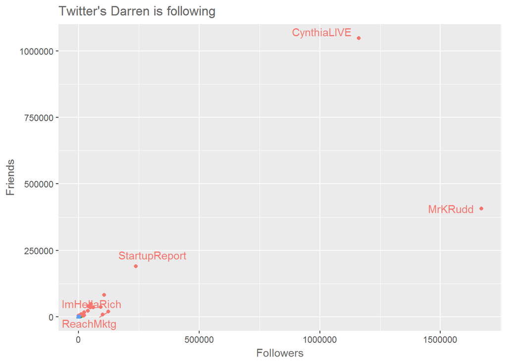

```r
ggplot(data=fol_txt, aes(x=cnt_follow, y=cnt_friend)) +
    ggtitle("Twitter's Darren is following") +
    xlab("Followers") +
    ylab("Friends") +
   geom_point(aes(shape=ANZ, colour=ANZ)) +
    geom_text_repel( data=filter(fol_txt, (cnt_follow>=100000 | cnt_friend >= 100000)),
                     aes(
                      color = factor(ANZ),
                       label = txt_nam
                     ),
                     point.padding = unit(0.25, "lines"),
                     box.padding = unit(0.25, "lines"),
                     nudge_y = 0.1
    ) +
    theme(
      legend.position = "none",
      axis.title.x = element_text(colour = "grey40"),
      axis.title.y = element_text(colour = "grey40"),
      plot.title = element_text(colour = "grey40")
    )
```

With such outliers in the data, its hard to understand where Darren falls in all this. So I decided to scale and remove the outliers.

```r
  # scale the data
  z <- scale(fol_txt[,2:3])

  #est a spread based upon the scaled mean
  score <- apply(z, 1, mean)

  # classify the data based upon spread
  y <- quantile(score, c(.8,.6,.4,.2))
  fol_txt$Q[score >=y[1]] <- "A"
  fol_txt$Q[score < y[1] & score >= y[2]] <- "B"
  fol_txt$Q[score <y[2] & score >= y[3]] <- "C"
  fol_txt$Q[score < y[3] & score >= y[4]] <- "D"
  fol_txt$Q[score < y[4]] <- "E"

  #subset the data, removing the top and bottom classifications
  sub_fol_txt <- subset(fol_txt, Q %in% c("B", "C", "D"))

  #update titles used in the graph
  sub_fol_txt$lab <- ifelse(sub_fol_txt$cnt_friend>=2000, sub_fol_txt$txt_nam,
                            (ifelse(sub_fol_txt$cnt_follow>=2000, sub_fol_txt$txt_nam,
                                    (ifelse(sub_fol_txt$txt_nam=="abbruzzd","abbruzzd", "")))))
```

Now with a limited dataset, we can revisit the graph

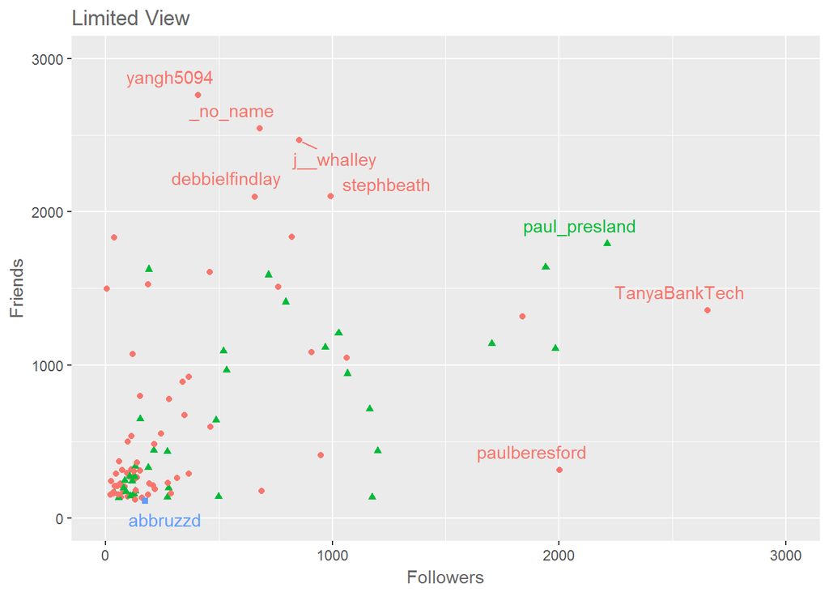

```r
 ggplot(data=sub_fol_txt, aes(x=cnt_follow, y=cnt_friend)) +
    ggtitle("Limited View") +
    xlab("Followers") +
    ylab("Friends") +
    geom_point(aes(shape=ANZ, colour=ANZ)) +
    scale_y_continuous(limits = c(0, 3000)) +
    scale_x_continuous(limits = c(0, 3000)) +
    geom_text_repel( data=filter(sub_fol_txt, !is.na(lab)),
      aes(
        color = factor(ANZ),
        label = lab
      ),
      point.padding = unit(0.25, "lines"),
      box.padding = unit(0.25, "lines"),
      nudge_y = 0.1
    ) +
    theme(
      legend.position = "none",
      axis.title.x = element_text(colour = "grey40"),
      axis.title.y = element_text(colour = "grey40"),
      plot.title = element_text(colour = "grey40")
    )
```

While this is a better view, even with these adjustments Darren still struggles to stand out.

Prehaps its an ANZ thing? I decided to limit the dataset to just people who self-identifed in their description as ANZ.  
For context I added a liner regression to get a sense of context.

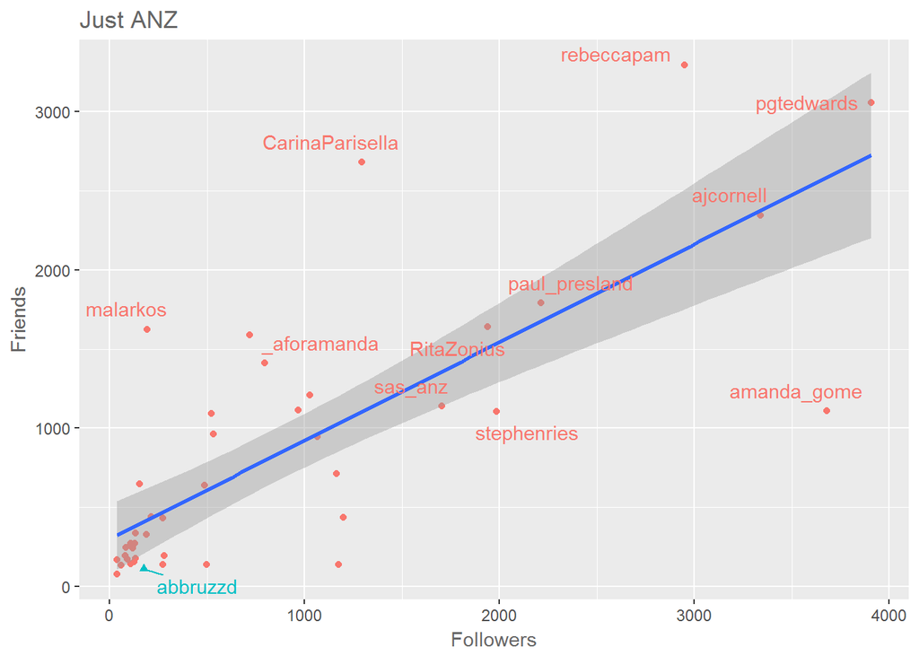

```r
#subset to just ANZ
  ANZ_fol_txt <- subset(fol_txt, (ANZ==TRUE | txt_nam=="abbruzzd"))
  ANZ_fol_txt$lab <- ifelse(ANZ_fol_txt$cnt_friend>=1500, ANZ_fol_txt$txt_nam,
                            (ifelse(ANZ_fol_txt$cnt_follow>=1500, ANZ_fol_txt$txt_nam,
                                    (ifelse(ANZ_fol_txt$txt_nam=="abbruzzd","abbruzzd", "")))))

  #ANZ view
  ggplot(data=ANZ_fol_txt, aes(x=cnt_follow, y=cnt_friend)) +
    ggtitle("Just ANZ") +
    xlab("Followers") +
    ylab("Friends") +
    geom_point(aes(shape=ANZ, colour=ANZ)) +
    geom_smooth(method='lm') +
    geom_text_repel( data=filter(ANZ_fol_txt, !is.na(lab)),
                     aes(
                       color = factor(ANZ),
                       label = lab
                     ),
                     point.padding = unit(0.25, "lines"),
                     box.padding = unit(0.25, "lines"),
                     nudge_y = 0.1
    ) +
    theme(
      legend.position = "none",
      axis.title.x = element_text(colour = "grey40"),
      axis.title.y = element_text(colour = "grey40"),
      plot.title = element_text(colour = "grey40")
    )
```

Ok, prehaps the story is different for Darren’s Friends?

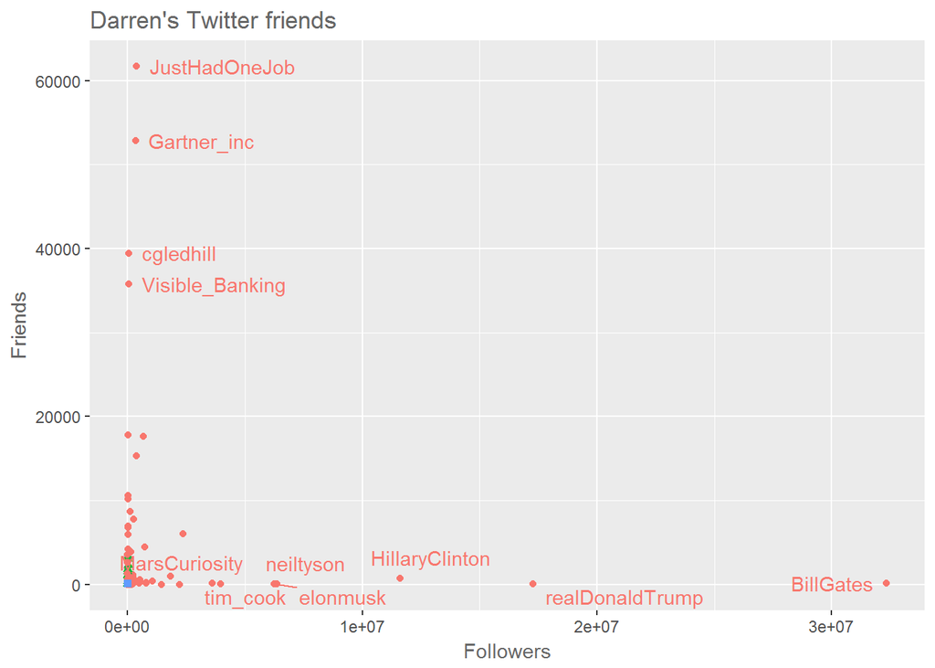

```r
  ggplot(data=frd_txt, aes(x=cnt_follow, y=cnt_friend)) +
    ggtitle("Darren's Twitter friends") +
    xlab("Followers") +
    ylab("Friends") +
    geom_point(aes(shape=ANZ, colour=ANZ)) +
    geom_text_repel( data=filter(frd_txt, (cnt_follow>=2500000 | cnt_friend >= 20000)),
                     aes(
                        color = factor(ANZ),
                       label = txt_nam
                     ),
                     point.padding = unit(0.25, "lines"),
                     box.padding = unit(0.25, "lines"),
                     nudge_y = 0.1
    ) +
    theme(
      legend.position = "none",
      axis.title.x = element_text(colour = "grey40"),
      axis.title.y = element_text(colour = "grey40"),
      plot.title = element_text(colour = "grey40")
    )
```

As before outliers obscure understanding, scaling will help again.

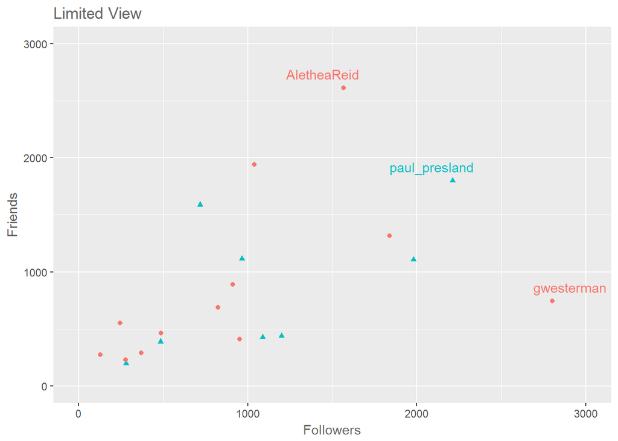

```r
  z <- scale(frd_txt[,2:3])
  score <- apply(z, 1, mean)

  y <- quantile(score, c(.8,.6,.4,.2))
  frd_txt$Q[score >=y[1]] <- "A"
  frd_txt$Q[score < y[1] & score >= y[2]] <- "B"
  frd_txt$Q[score <y[2] & score >= y[3]] <- "C"
  frd_txt$Q[score < y[3] & score >= y[4]] <- "D"
  frd_txt$Q[score < y[4]] <- "E"

  sub_frd_txt <- subset(frd_txt, Q %in% c("B", "C", "D"))

  #update titles
  sub_frd_txt$lab <- ifelse(sub_frd_txt$cnt_friend>=2000, sub_frd_txt$txt_nam,
                            (ifelse(sub_frd_txt$cnt_follow>=2000, sub_frd_txt$txt_nam,
                                    (ifelse(sub_frd_txt$txt_nam=="abbruzzd","abbruzzd", "")))))

  #limited view
  ggplot(data=sub_frd_txt, aes(x=cnt_follow, y=cnt_friend)) +
    ggtitle("Limited View") +
    xlab("Followers") +
    ylab("Friends") +
    geom_point(aes(shape=ANZ, colour=ANZ)) +
    scale_y_continuous(limits = c(0, 3000)) +
    scale_x_continuous(limits = c(0, 3000)) +
    geom_text_repel( data=filter(sub_frd_txt, !is.na(lab)),
                     aes(
                       color = factor(ANZ),
                       label = lab
                     ),
                     point.padding = unit(0.25, "lines"),
                     box.padding = unit(0.25, "lines"),
                     nudge_y = 0.1
    ) +
    theme(
      legend.position = "none",
      axis.title.x = element_text(colour = "grey40"),
      axis.title.y = element_text(colour = "grey40"),
      plot.title = element_text(colour = "grey40")
    )
```

Once again, lets try just the ANZ accounts, with a liner regression to help understand the baseline;

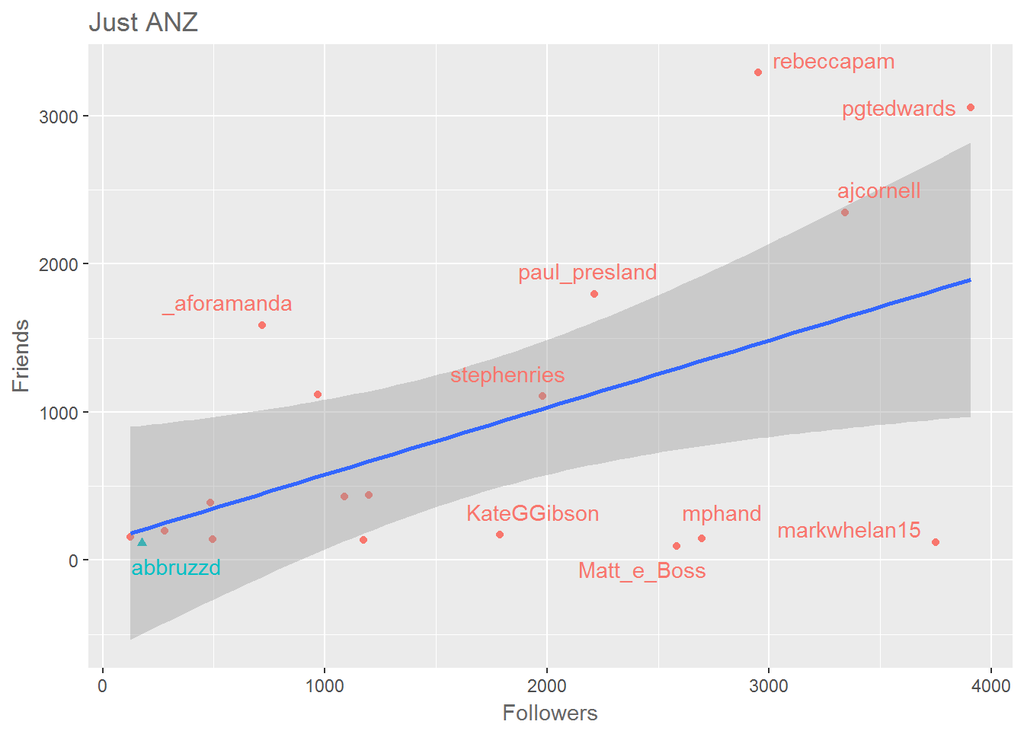

```r
  #subset for ANZ
  ANZ_frd_txt <- subset(frd_txt, (ANZ==TRUE | txt_nam=="abbruzzd"))
  ANZ_frd_txt$lab <- ifelse(ANZ_frd_txt$cnt_friend>=1500, ANZ_frd_txt$txt_nam,
                            (ifelse(ANZ_frd_txt$cnt_follow>=1500, ANZ_frd_txt$txt_nam,
                                    (ifelse(ANZ_frd_txt$txt_nam=="abbruzzd","abbruzzd", "")))))

  #ANZ view
  ggplot(data=ANZ_frd_txt, aes(x=cnt_follow, y=cnt_friend)) +
    ggtitle("Just ANZ") +
    xlab("Followers") +
    ylab("Friends") +
    geom_point(aes(shape=ANZ, colour=ANZ)) +
    geom_smooth(method='lm') +
    geom_text_repel( data=filter(ANZ_frd_txt, !is.na(lab)),
                     aes(
                       color = factor(ANZ),
                       label = lab
                     ),
                     point.padding = unit(0.25, "lines"),
                     box.padding = unit(0.25, "lines"),
                     nudge_y = 0.1
    ) +
    theme(
      legend.position = "none",
      axis.title.x = element_text(colour = "grey40"),
      axis.title.y = element_text(colour = "grey40"),
      plot.title = element_text(colour = "grey40")
    )
```

#### *Conclusion*

Prehaps the Microsoft API for [Emotion](https://www.microsoft.com/cognitive-services/en-us/emotion-api) using Darrens Twitter photo best expresses this analysis.

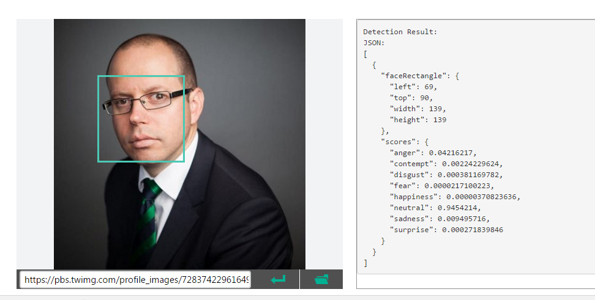

#### *Notes*

The Key notes of this analysis are:

- it should be noted, these stats change on a daliy basis. Different days will get different results.
- The original idea for this is [Jeff’s Leaks](http://biostat.jhsph.edu/~jleek/code/twitterMap.R)
- The MS API Inspiration follows from [here](https://www.r-bloggers.com/election-2016-tracking-emotions-with-r-and-python/)

**– end of document –**